# First active learning exercise

### By William Martinez

Accuracy in a supervised classification of a satellite image can depend on several factors such as quality of the training data, type of algorithm, explanatory variables, minimum mapping unit and so on. I want with this report to identify the training data that support the most to the classification performance of one image of 2017 covering the center of Portugal. Also, this can lead to identifying how spatially the accuracy response to the data so that we can identify hotspot and therefore an exploration of more data.

I will start calling the packages that we will use during this session such as skelearn, pandas, ogr and numpy.

```python
import sklearn
from sklearn.datasets import load_iris
from sklearn.preprocessing import MinMaxScaler
import numpy as np
from sklearn.metrics import accuracy_score
from sklearn.svm import SVC
import pandas as pd
```

Let's call the shapefile using following function

```python
from osgeo import gdal, ogr

def import_data_shp(path_shape):
    driver = ogr.GetDriverByName("ESRI Shapefile")
    data_source =  driver.Open(path_shape)
    layer =  data_source.GetLayer()
    layer_defn = layer.GetLayerDefn()
    count_field = layer_defn.GetFieldCount()
    print(layer_defn.GetFieldDefn(0).GetType)
    fc = layer.GetFeatureCount()  # number of rows
    proj = layer.GetSpatialRef()  #projection
    #Getting name of the fields of the Shapefile
    schema = []
    #variables
    for k in range(0,count_field):
        f_field = layer_defn.GetFieldDefn(k)
        schema.append(f_field.name)
    #importing features
    x = []
    y = []
    data = []
    coordinates = []
    sp_obj = {}
    for feat in layer:
        #coordinates
        pt = feat.geometry()
        coord_par = [pt.GetX(),pt.GetY()]
        coordinates.append(coord_par)
        #variables
        fields = []
        for i in range(0, count_field):
            f = feat.GetField(i)
            fields.append(f)
        #second part
        data.append(fields)
    #array of data in data frame format
    #for string
    dataset = pd.DataFrame(data,columns = schema)
    #coordinates
    coord_df = pd.DataFrame(np.array(coordinates),columns = ["x","y"])
    sp_obj = {
    "coordinates":coord_df,
    "data":dataset,
    "proj":proj
    }
    #returning object
    return(sp_obj)
```

Once we have created the function, I want to call a dataset that consists of 6 categories of land cover that are uniformly distributed in the sampling, 700 samples by category. In this context, our classes are 'herbaceous', 'Non--vegetated', 'sealed', 'water', 'wetlands', 'woody'.

```python
shapefile = 'IM_20170729/training_samples11.shp'
dataset = import_data_shp(shapefile)['data']
```

```
<bound method FieldDefn.GetType of <osgeo.ogr.FieldDefn; proxy of <Swig Object of type 'OGRFieldDefnShadow *' at 0x7fcf01ccf8d0> >>
```

Once the dataset is in this environment, we will implement a normalization and thereafter active learning procedures using support vector machine as predictor

```python
#Normalization

class Normalize:

    print('Normalizing min-max')

    def normalize(self, X):
        self.scaler = MinMaxScaler()
        X_normal = self.scaler.fit_transform(X)
        return (X_normal)

#random selection

def split(dataset,size_train):
    #size of the dataset
    n_x,n_y = dataset.shape
    y = dataset.CLASS_NAME.values
    X = dataset.iloc[:,1:].values
    X_n = Normalize()
    X_normal = X_n.normalize(X)
    #random index
    np.random.seed(1)
    index_random = np.random.choice(X_normal.shape[0],X_normal.shape[0], replace= False)
    #counting
    st = np.int(n_x*size_train)
    #train
    X_train = X_normal[index_random[:st]]
    y_train = y[index_random[:st]]
    #test
    X_test = X_normal[index_random[st:]]
    y_test = y[index_random[st:]]
    return(X_train, y_train, X_test, y_test)


#Entropies

class measureselection():
    def EntropySelection(self, probabilities):
        def entropyfunc(x):
            #ind = np.where(x != 0)[0]
            e = -(x * np.log2(x)).sum()
            return(e)
        #implementing function
        entropy = np.apply_along_axis(entropyfunc, 1, probabilities)
        #fransforming entropie values in probabilities using sof-max function
        def softmax(y):
            delta = np.exp(y)/np.sum(np.exp(y))
            return delta
        self.entropy = softmax(entropy)
        #print(self.entropy.shape)
        return(self.entropy)

class SvmModel():
    model_type = 'Support Vector Machine with rbf Kernel'
    def fit_predict(self, X_val, y_val, X_train, X_test):
        #print ('training svm...')
        self.classifier = SVC(C=2, kernel = 'rbf',gamma= 0.25, probability=True)
        self.classifier.fit(X_val, y_val)
        self.train_y_predicted = self.classifier.predict(X_train)
        self.test_y_predicted = self.classifier.predict(X_test)
        self.train_y_probability = self.classifier.predict_proba(X_train)
        return(self.train_y_predicted , self.train_y_probability, self.test_y_predicted)
```

```
Normalizing min-max
```

The above functions support the fowllowing code. I am basically running a sort of boosting

```python
a = 200
q = 20
X_train, y_train, X_test, y_test =  split(dataset,size_train = 0.7)
n,_= X_train.shape
prob = np.repeat(1/n,n).tolist()
dict_oa = {}
OA_train_list = []
OA_test_list = []
for i in range(a,n,q):
    #weigthed random selection
    l =  np.random.choice(n,i,replace=False,p=prob)
    X_val = X_train[l]
    y_val = y_train[l]
    svm = SvmModel()
    train_y_predicted , train_y_probability, test_y_predicted = svm.fit_predict(X_val, y_val, X_train, X_test)
    OA_train = accuracy_score(train_y_predicted, y_train)
    OA_test = accuracy_score(test_y_predicted, y_test)
    #print(f'Overall accuracy training set {OA_train}')
    #print(f'Overall accuracy test set {OA_test}')
    #saving data in a dictionary
    OA_train_list.append(OA_train)
    OA_test_list.append(OA_test)
    #updating again porbabilities
    ms =  measureselection()
    prob = ms.EntropySelection(train_y_probability).tolist()

dict_oa["iter"] =  list(range(a,n,q))
dict_oa["train"] = OA_train_list
dict_oa["test"] =  OA_test_list

#plot
df = pd.DataFrame.from_dict(dict_oa)
```

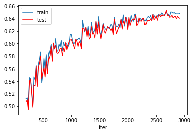

```python
#visualiztion
import matplotlib.pyplot as plt
ax = plt.gca()

df.plot(kind='line', x ='iter', y = 'train', ax=ax)
df.plot(kind='line', x ='iter', y = 'test',color='red',  ax=ax)
plt.show()
```

What makes special this graphic is the range of the curve. Once the curve reaches 2000 samples the accuracy starts to stabilize and become linear, so that we find redundant data that not support anymore a better performance in the prediction. With this script, we set out the search for which samples are those which leads to explain this variability...